# Model Details for EarthQuakeAnalyzer package

Daniel Ayllón

6 May 2017

# R EarthQuakeAnalyzer package

The R EarthQuakeAnalyzer package was developed to work with the NOAA Significant Earthquakes dataset.

The package incorporate tools for processing and visualizing the dataset obtained from the U.S. National Oceanographic and Atmospheric Administration (NOAA) on significant earthquakes around the world. This dataset contains information about 5,933 earthquakes over an approximately 4,000 year time span. The dataset is included in the package in a data frame format - `EarthquakeDataFrame` - to be loaded through the data() function. Likewise, the raw data - `signif.txt` - is stored in the `inst/extdata` directory so that it can be accessed.

It includes tools for: (1) reading and cleaning the dataset, (2) adding a geom instance to a ggplot object to plot a timeline of selected earthquakes providing information about the magnitude and number of deaths, and (3) creating a leaflet fully interactive map showing the location of epicenters of selected earthquakes with information regarding the magnitude and number of deaths.

## Required packages

The R Assignment package requires functions from the readr, dplyr, tidyr, lubridate, stringr, ggplot2, grid and leaflet R packages.

```r
library(readr)
library(dplyr)
library(tidyr)
library(lubridate)
library(stringr)
library(ggplot2)
library(grid)
library(leaflet)
```

### Functions for processing and cleaning the data

#### eq_clean_data() Function

This function reads the raw earthquake dataset in a tab-delimited format to clean some of the variables. The function first checks whether the file to be read actually exists.If it does not exist, then it downloads from the NOOA website.Then, the function adds a date column created by uniting the year, month, day of each earthquake and converting it to the Date class. It filters the earthquakes without a complete date.

It has only one argument, `filename`, a character vector of the name of the tab-delimited text file to be read.

Here, it is read and stored the file:

```r
tail(eq_clean_data("signif.txt"))
```

```
## # A tibble: 6 × 46
##     I_D FLAG_TSUNAMI  YEAR   DATETIME  HOUR MINUTE SECOND FOCAL_DEPTH
##   <int>        <chr> <dbl>     <date> <int>  <int>  <chr>       <int>
## 1 10239         <NA>  2017 2017-03-13    14     19    6.0          10
## 2 10240         <NA>  2017 2017-04-05     6      9   12.0          13
## 3 10242         <NA>  2017 2017-04-08     7      9   27.0          43
## 4 10241         <NA>  2017 2017-04-10    23     53   58.0          10
## 5 10244          Tsu  2017 2017-04-24    21     38   26.0          25
## 6 10245          Tsu  2017 2017-04-28    20     23   17.0          26
## # ... with 38 more variables: EQ_PRIMARY <dbl>, EQ_MAG_MW <chr>,
## #   EQ_MAG_MS <chr>, EQ_MAG_MB <chr>, EQ_MAG_ML <dbl>, EQ_MAG_MFA <chr>,
## #   EQ_MAG_UNK <chr>, INTENSITY <int>, COUNTRY <chr>, STATE <chr>,
## #   LOCATION_NAME <chr>, LATITUDE <dbl>, LONGITUDE <dbl>,
## #   REGION_CODE <int>, DEATHS <chr>, DEATHS_DESCRIPTION <int>,
## #   MISSING <chr>, MISSING_DESCRIPTION <int>, INJURIES <chr>,
## #   INJURIES_DESCRIPTION <int>, DAMAGE_MILLIONS_DOLLARS <chr>,
## #   DAMAGE_DESCRIPTION <int>, HOUSES_DESTROYED <int>,
## #   HOUSES_DESTROYED_DESCRIPTION <int>, HOUSES_DAMAGED <int>,
## #   HOUSES_DAMAGED_DESCRIPTION <int>, TOTAL_DEATHS <dbl>,
## #   TOTAL_DEATHS_DESCRIPTION <int>, TOTAL_MISSING <chr>,
## #   TOTAL_MISSING_DESCRIPTION <chr>, TOTAL_INJURIES <int>,
## #   TOTAL_INJURIES_DESCRIPTION <int>, TOTAL_DAMAGE_MILLIONS_DOLLARS <chr>,
## #   TOTAL_DAMAGE_DESCRIPTION <int>, TOTAL_HOUSES_DESTROYED <int>,
## #   TOTAL_HOUSES_DESTROYED_DESCRIPTION <int>, TOTAL_HOUSES_DAMAGED <int>,
## #   TOTAL_HOUSES_DAMAGED_DESCRIPTION <int>
```

#### eq_location_clean() Function

The package includes a function to clean up the “LOCATION_NAME” column from either the downloaded raw dataset or the processes dataframe, as cleaned by the eq_clean_data() function.

The function returns a dataframe with the column “LOCATION_NAME” cleaned by stripping out the country name (including the colon) and convert names to title case (as opposed to all caps).The dataframe to be cleaned is given by the input parameter `EarthquakeData`, the only argument of the function.

Here, the dataframe processed in the previous example gets the “LOCATION_NAME” cleaned:

```r
eq_clean_data("signif.txt") %>% eq_location_clean() %>% select(DATETIME,EQ_PRIMARY,LOCATION_NAME) %>% tail()
```

```
##        DATETIME EQ_PRIMARY          LOCATION_NAME
## 5374 2017-03-13        5.1            Tharrawaddy
## 5375 2017-04-05        6.1             Sefid Sang
## 5376 2017-04-08        5.9   Batangas, Calabarzon
## 5377 2017-04-10        4.8 San Salvador,Soyapango
## 5378 2017-04-24        6.9             Valparaiso
## 5379 2017-04-28        6.9              Sarangani
```

### Functions for plotting the data with ggplot2

#### geom_timeline() Function

This function reads the raw earthquake dataset in a dataframe format to create a ggplot geom that plots a time line of earthquakes ranging from the minimum to the maximum dates with a point for each earthquake.

The `x` aesthetic is a date and an optional `y` aesthetic is a factor that stratifies the data by country, in which case multiple time lines will be plotted, one for each country.

In addition to showing the dates on which the earthquakes occur, it is also possible to show the magnitudes (i.e. Richter scale value) and the number of deaths associated with each earthquake, which are input via the `size` and `fill` and `colour` optional aesthetics.

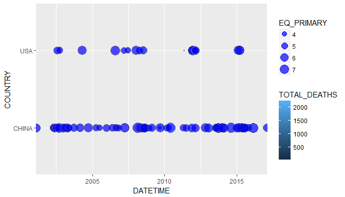

```r
quakedata<-eq_clean_data("signif.txt") %>%
  filter(year(DATETIME)>2000 & COUNTRY==c("USA","CHINA"))
ggplot() + geom_timeline(data = quakedata,aes(x = DATETIME, y = COUNTRY, size = EQ_PRIMARY, colour = TOTAL_DEATHS))
```

#### geom_timeline_label() Function

This function reads an Earthquake dataset in a dataframe format to create annotations to the plotted data.This geom adds a vertical line to each data point with a text annotation showing the location (or other information) of the earthquake attached to each line.

The `x` aesthetic is a date and an optional `y` aesthetic is a factor that stratifies the data by country, in which case multiple time lines will be plotted, one for each country. The `label` aesthetic typically indicates the name of the location of the earthquake (but other information can be dislayed).

There is also the option to subset to n_max number of earthquakes, where the function takes the `n_max` largest (by magnitude) earthquakes. The aesthetics `magnitude` sets the column conatining the info of earthquake’s magnitude.

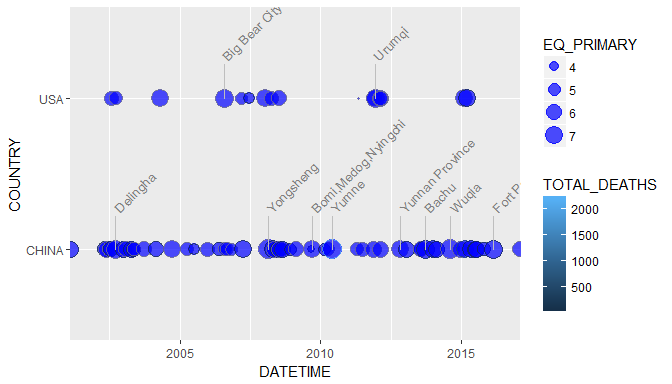

```r
quakedata<-eq_clean_data("signif.txt") %>% eq_location_clean() %>%
  filter(year(DATETIME)>2000 & COUNTRY==c("USA","CHINA"))
ggplot() + geom_timeline(data = quakedata,aes(x = DATETIME, y = COUNTRY, size = EQ_PRIMARY, colour = TOTAL_DEATHS)) + geom_timeline_label(data = quakedata,aes(x = DATETIME, label = LOCATION_NAME,y = COUNTRY, n_max = 10, magnitude = EQ_PRIMARY)) + scale_color_gradient()
```

### Functions for mapping the data in a in a leaflet interactive map

#### eq_map() Function

This function reads a filtered data frame with earthquakes selected to visualize. The function maps the epicenters (LATITUDE/LONGITUDE) and annotates each point in a pop-up window containing annotation data stored in a column of the data frame. Each earthquake is shown with a circle, and the radius of the circle is proportional to the earthquake’s magnitude.

It requires the input parameters `dataframe`, a filtered dataframe, and `annot_col`, a character vector that indicates which column is used for the annotation in the pop-up window.

Here, the function creates a leaflet interactive map showing the epicenter of the earthquakes in Mexico since year 2000:

```r
eq_clean_data("signif.txt") %>%
dplyr::filter(COUNTRY == "MEXICO" & lubridate::year(DATETIME) >= 2000) %>%
eq_map(annot_col = "DATETIME")
```

[interactive chart not shown]

#### eq_create_label() Function

This function takes the filtered and cleaned dataframe as an argument and creates an HTML label that can be used as the annotation text in a leaflet map created by eq_map().

This function puts together a character string for each earthquake that shows the cleaned location (as cleaned by the eq_location_clean() function), the magnitude, and the total number of deaths, with boldface labels for each. If an earthquake is missing values for any of these, both the label and the value are skipped for that element of the tag.

The only input parameter is `dataframe`, a dataframe that has been cleaned by the eq_location_clean() function.

Here, the function creates a label to be used in a leaflet interactive map showing the epicenter of the earthquakes in Mexico since year 2000:

```r
eq_clean_data("signif.txt") %>%
dplyr::filter(COUNTRY == "MEXICO" & lubridate::year(DATETIME) >= 2000) %>%
eq_location_clean() %>%
eq_create_label() %>%
eq_map(annot_col = "popup_text")
```

[interactive chart not shown]